# Empirical Bayesian Estimation

Jim Hughes

4 September 2019

## Aim

This document aims to provide a workflow for empirical Bayesian estimation using the `PKADVAN` package in R. Each step covered is accompanied by an example script. The steps covered by this manuscript are:

- Simulation of “observed data” using `PKADVAN`
- Utilising empirical Bayesian estimation to obtain individual pharmacokinetic parameters
- Evaluation of empirical Bayes estimates

```r
# Load libraries
  library(PKADVAN)
  library(plyr)
  library(data.table)
  library(MASS)
  library(ggplot2)
```

## Overview

For a given set of observed pharmacokinetic data for which there is an existing population pharmacokinetic model, the individual pharmacokinetic parameters (clearance, CL; volume of distribution, Vd etc.) can be obtained using empirical Bayesian estimation. These individual parameters are also known as empirical Bayesian estimates (EBEs).

Software such as NONMEM provide EBEs as a part of it’s post-hoc analysis. While this is often considered the easiest way to get EBEs, there are cases where the use of NONMEM is not practical, feasible or optimal. Fortunately, EBEs can be obtained using R, by utilising packages such as `mrgsolve`, `RxODE`, `deSolve` and `PKADVAN`.

Bayesian forecasting is a method of extrapolating from observed data to predict future events. With pharmacokinetic data, this is done to predict patient exposure after given certain doses with the aim of optimising that dose to maximise efficacy and minimise toxicity. Bayesian forecasting uses EBEs to make it’s predictions.

### R Packages

The three differential equation solver packages `mrgsolve`, `RxODE` and `deSolve` allow the user to define any model, while `PKADVAN` is limited to the pre-defined model types within the package due to it’s use of analytical solutions. The requirement of an R tools installation for `mrgsolve` and `RxODE` may cause difficulties on some systems, making `deSolve` and `PKADVAN` easier to use with little setup required. While `mrgsolve`, `RxODE` and `PKADVAN` work using similar datasets and workflows to those seen in NONMEM, while `deSolve` is structured somewhat differently making its use less intuitive for NONMEM users.

In this document R version 3.4.4 was used with the following packages:

- `PKADVAN` ver. 0.1.0
- `plyr` ver. 1.8.4
- `data.table` ver. 1.12.2
- `MASS` ver. 7.3.51.4
- `ggplot2` ver. 3.1.1

## Observed Data

The observed data used to obtain EBEs will need to be in a long-format (also known as NONMEM-format), as typically used in NONMEM. This data format describes in each row, data that describes the dose and concentrations at each time. The `prepare_data_workflow` series of documents (.R, .Rmd, .html) give detailed examples of how to prepare long-format data.

For this document, an example dataset will be simulated. It should be noted that the process describing simulation is not necessary if observed data is available. However, it may help readers to understand how `PKADVAN` simulation works, as it is a crucial part of empirical Bayesian estimation. Additionally, users will be required to make model-specific simulation code whenever performing empirical Bayesian estimation.

Simulating observed data requires:

- a population pharmacokinetic model
- a description of the population of interest
- a drug regimen describing dose and concentration times

These three components are defined in `pkadvan_simulation.R`.

### Population Pharmacokinetic Model

Population pharmacokinetic models used with `PKADVAN` must match one of the pre-defined model types in its library of models. These 26 models include:

- Basic Pharmacokinetic models
  - 1, 2 or 3 compartments
  - IV bolus, IV infusion or oral administration
- Transit First-Order Absorption Models
  - 1 or 2 compartments
  - 1, 2, 3 or 4 transits
- First-Order Formation Metabolite Models
  - 1, 2 or 3 compartments for parent, 1 compartment for metabolite
  - IV bolus, IV infusion or oral administration

Models that do not fit under these model types cannot be simulated by `PKADVAN`. `PKADVAN` works with time-varying covariates, but only updates the value of the covariate for each value provided by the original data. Care should be taken simulating sparse regimens when models incorporate time-varying covariates.

In this document we pharmacokinetic model of interest is for vemurafenib. It is published in the Clinical Pharmacology and Biopharmaceutics Review for Vemurafenib (Application Number: 202429Orig1s000) submitted to the FDA. The original model can be found on page 50, with an FDA-revised model on page 60.

The FDA revised model is presented below. The use of the `list()` function is not mandatory, but is used here to keep all information required for the use of the model in one R object.

```r
# Define pharmacokinetic model
# The pharmacokinetics of vemurafenib are explained by a one-compartment model
#   with first order absorption & first order elimination.
# Model was built using BRIM2, BRIM3 and an unavailable Phase I dataset
# PKADVAN function for this is: PKADVAN::OneCompFirstOrderAbs
# Requires parameters for F1, KA, CL & V (found using ?PKADVAN::OneCompFirstOrderAbs)
# Order and naming doesn't matter *here*, just a way of keeping our model
#   parameters tidy and not scattered into the global environment.
  pk_mod <- list(
  # Population Parameters
    POPCL = 1.3,  # apparent clearance; L/h
    POPV = 106,  # apparent volume; L
    POPKA = 0.188,  # absorption constant; h-1
    POPF1 = 1,  # relative bioavailability, DAY >= 105
  # Covariate Effects
    REFWT = 70,
    WTonCL = 0.319,
    WTonV = 0.740,
    Tlt14onF1 = 0.789,  # relative bioavailability, DAY <= 14  # only on BRIM2
    Tlt104onF1 = 0.899,  # relative bioavailability, DAY > 15 & DAY <= 104  # only on BRIM2
  # Population Parameter Variability
    PPVCL = 0.319,  # apparent clearance variability; CV (coefficient of variation)
    PPVV = 0.657,  # apparent volume variability; CV
    PPVKA = 1.01,  # absorption constant variability; CV
  # Residual Unexplained Variability
    RUVADD = 0.814,  # additive error; mg/L
    RUVPRO = 0.228  # proportional error; CV
  )
```

### Population of Interest

Given that the population pharmacokinetic model includes weight this must be specified for each patient, when defining the population of interest. If using observed data, then these are the demographic data that need to be extracted the available subject-level data.

When simulating pharmacokinetic data, covariate data can be sampled from a random distribution. The mean and standard deviation of the covariate, as well as the shape of the distribution (normal vs. log-normal) should be considered. In this example a normal distribution is assumed for simplicity, with a mean weight of 70 kg and standard deviation of 5 kg.

Additionally, as we are simulating pharmacokinetic data in this example, a description of the population parameter variability for each patient `ETA` is sampled from a normal distribution with a mean of zero and standard deviation equal to the square root of the variance associated with each population parameter `PPV`.

```r
# Create subject level data
# Define subject numbers
  nid <- 60
  ID <- 1:nid

# Sample Individual Population Parameters
  pop_tbl <- data.table(
    STUDYID = rep(c("BRIM2", "BRIM3", "coBRIM"), each = 20),
    SUBJID = ID,
    ETA1 = rnorm(nid, 0, sd = sqrt(pk_mod$PPVCL)),
    ETA2 = rnorm(nid, 0, sd = sqrt(pk_mod$PPVV)),
    ETA3 = rnorm(nid, 0, sd = sqrt(pk_mod$PPVKA)),
    WT = rnorm(nid, 70, sd = 5)
  )
```

### Drug Regimen

The drug regimen defines when doses are given to patients, in addition to times at which concentration predictions are desired (or are available with observed data). For observed data, this is obtained through the preparation of the data in a long-format. When simulating data, these must be defined.

The regimen outlined below follows the protocol for dosing and plasma-samples of the BRIM2, BRIM3 and coBRIM vemurafenib clinical trials. Each trial is assigned 20 patients.

```r
# Create longitudinal data
# Dose data
  dose_times <- seq(0, 1020, by = 12)
  dose_tbl <- data.table(
    SUBJID = rep(ID, each = length(dose_times)),
    TIME = dose_times,
    AMT = 960,
    MDV = 1,
    DV = 0
  )

# Concentration data
  conc_times_brim2 <- as.numeric(outer(c(-0.25, 2, 4, 6, 8), c(0, 360, 504, 1008), FUN = "+"))
  conc_brim2 <- data.table(
    SUBJID = rep(ID[1:20], each = length(conc_times_brim2)),
    TIME = rep(conc_times_brim2, nid/3),
    AMT = 0,
    MDV = 0,
    DV = 0
  )
  conc_times_brim3 <- as.numeric(outer(c(-0.25, 2.5), c(0, 360, 504), FUN = "+"))
  conc_brim3 <- data.table(
    SUBJID = rep(ID[21:40], each = length(conc_times_brim3)),
    TIME = rep(conc_times_brim3, nid/3),
    AMT = 0,
    MDV = 0,
    DV = 0
  )
  conc_times_cobrim <- as.numeric(outer(c(-0.25, 3), c(0, 360, 672), FUN = "+"))
  conc_cobrim <- data.table(
    SUBJID = rep(ID[41:60], each = length(conc_times_cobrim)),
    TIME = rep(conc_times_cobrim, nid/3),
    AMT = 0,
    MDV = 0,
    DV = 0
  )
  conc_tbl <- rbind(conc_brim2, conc_brim3, conc_cobrim)
  conc_tbl <- conc_tbl[TIME >= 0, ]

# Merge final dataset
  pk_tbl <- rbind(dose_tbl, conc_tbl)
  input_tbl <- merge(pop_tbl, pk_tbl, by = "SUBJID")
  setorder(input_tbl, SUBJID, TIME)
```

Using this drug regimen, along with the population data and pharmacokinetic model, the example pharmacokinetic data for this document is simulated below.

The following code showcases how `PKADVAN` is utilised. `PKADVAN` is only able to simulate the pharmacokinetic data of one patient at a time. Therefore, a function is defined to handle individual simulation of data `pkadvan_sim_fn`, which is then fed to a `ddply()` function to run the function on each subjects input data `input_tbl`, identifying each subject using the `SUBJID` column.

The `pkadvan_sim_fn` does the following:

- Converts the input data.frame containing a single individuals data into the data.table format
- Determines the individual parameter values for the patient based on their `ETA` values and their demographic data
  - The parameter values required is dependent on the `PKADVAN` model type used
    - In this example `OneCompFirstOrderAbs()` describes the vemurafenib model
    - The required parameter values are found by entering `??OneCompFirstOrderAbs`
    - This shows that input data must contain the following columns: `ID,` `TIME, AMT, F1, KA, CL, V`. `F1`, `KA`, `CL` and `V` are the parameter values.
  - The individual parameter values are calculated by multiplying the population parameter value with any covariate effects or population parameter variability defined in the model. e.g. `POPX * COVX * exp(ETAX)`
    - F1 only has a covariate effect if the patient is in the BRIM2 study, which varies dependent on whether the patient has been on the medication for longer than 14 days.
    - CL and V have a covariate effect (weight) `(WT/REFWT)^WTonCL` and population parameter variability `exp(ETA1)`.
    - KA only has population parameter variability `exp(ETA3)`.
- The `OneCompFirstOrderAbs()` function is given these values as input and simulates the individual predictions for plasma sample concentration values.
- Then the residual unexplained variability is added to the individual predictions to provide the observed data/dependent variable `DV`.
  - In this example the residual unexplained variability is defined using a weight term `W = sqrt( (IPRED*RUVPRO)^2) + RUVADD^2 )`.
  - This term describes a combined error model, made up of a proportional component `(IPRED*RUVPRO)^2)` and an additive component `RUVADD^2`.
  - The weight term is then multiplied by a randomly sampled value from a normal distribution with a mean of zero and standard deviation of 1 and added to the individual predicted concentration.
- Finally the data is cleaned up and the desired columns are returned as output from the function
  - Any observed data `DV` simulated below zero is corrected to zero and marked as missing using the `MDV` column. This is to match what would be seen in long-format observed data.
  - In this example only `"STUDYID", "SUBJID", "TIME"...`, when used with empirical Bayesian estimation individual parameter values are also returned.

```r
# Define simulation function
  pkadvan_sim_fn <- function(input_df) {
  # Define parameter values
    ipred_in <- as.data.table(input_df)
  # Bioavailability - time-varying covariate
    ipred_in[, DAY := TIME/24 + 1]
    ipred_in[, F1 := with(pk_mod, POPF1)]
    ipred_in[DAY <= 14 & STUDYID == "BRIM2", F1 := with(pk_mod, POPF1*Tlt14onF1)]
    ipred_in[DAY > 14 & STUDYID == "BRIM2", F1 := with(pk_mod, POPF1*Tlt104onF1)]
  # Clearance and volume - covariate and population parameter variability
    ipred_in[, CL := with(pk_mod, POPCL * (WT/REFWT)^WTonCL * exp(ETA1) )]
    ipred_in[, V := with(pk_mod, POPV * (WT/REFWT)^WTonV * exp(ETA2) )]
  # Absorption constant - population parameter variability
    ipred_in[, KA := with(pk_mod, POPKA * exp(ETA3) )]
  # Predict individual concentrations using PKADVAN
    ipred_out <- PKADVAN::OneCompFirstOrderAbs(ipred_in)
  # Sample residual unexplained variability
    ipred_out[, W := with(pk_mod, sqrt((IPRED*RUVPRO)^2) + RUVADD^2)]
    ipred_out[, DV := IPRED + W*rnorm(length(IPRED), 0, 1)]
  # Clean up and return data
    ipred_out[DV <= 0, DV := 0]
    ipred_out[DV <= 0, MDV := 1]
    ipred_out[, c("STUDYID", "SUBJID", "TIME", "AMT", "MDV", "DV", "WT", "DAY")]
  }
# Run simulation function
  pkdata <- as.data.table(ddply(input_tbl, .(SUBJID), pkadvan_sim_fn))
```

Using this dataset, Bayesian estimation be demonstrated. Here is an example of the simulation output.

```
##    STUDYID SUBJID TIME AMT MDV        DV       WT      DAY
## 1:   BRIM2      1    0 960   1 0.3016697 71.14986 1.000000
## 2:   BRIM2      1    2   0   0 0.5772188 71.14986 1.083333
## 3:   BRIM2      1    4   0   0 0.8965064 71.14986 1.166667
## 4:   BRIM2      1    6   0   0 1.6240131 71.14986 1.250000
## 5:   BRIM2      1    8   0   0 3.4056296 71.14986 1.333333
## 6:   BRIM2      1   12 960   1 2.1521100 71.14986 1.500000
```

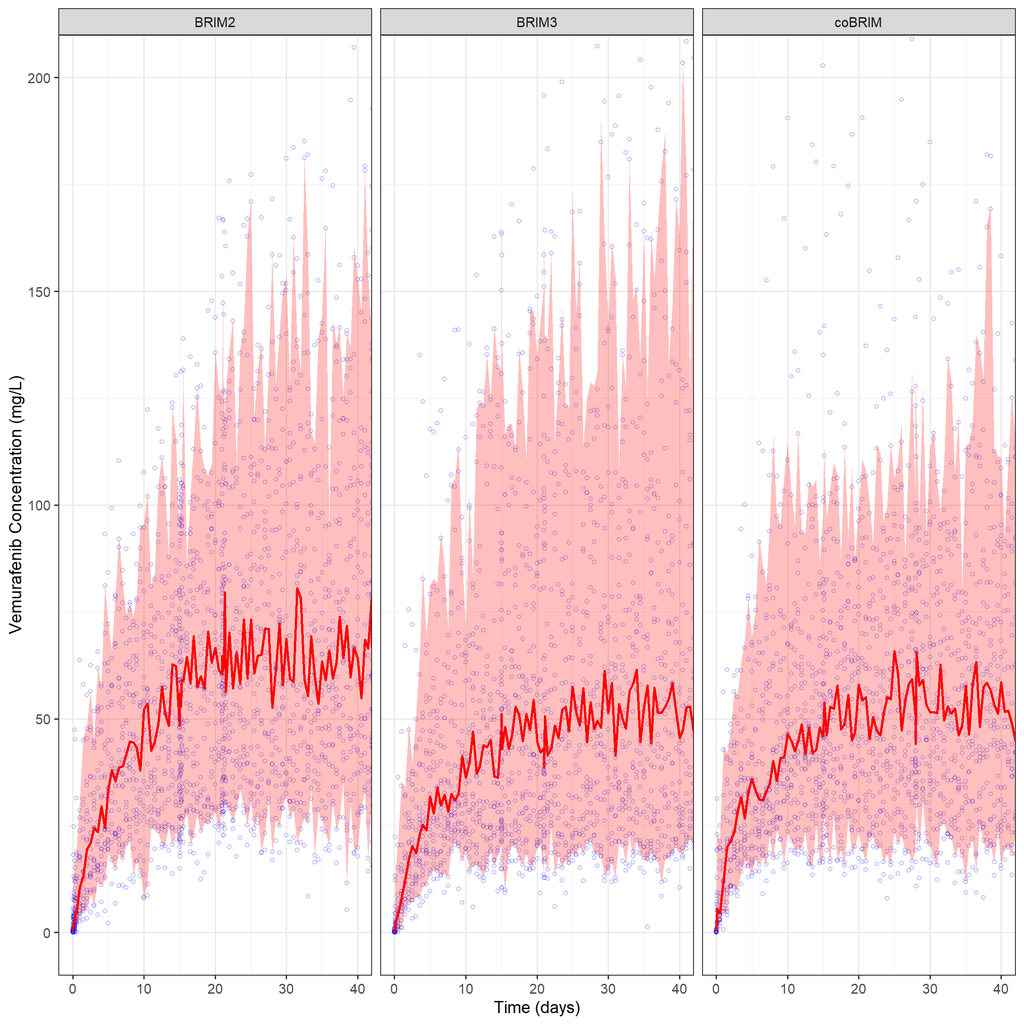

In this image the blue dots represent individual plasma concentrations, while the red line and ribbon represent the median along with the upper and lower 90% confidence intervals of the concentration over time.

Now that an example dataset has been created and a basic understanding of `PKADVAN` is obtained, empirical Bayesian estimation can begin.

## Empirical Bayesian Estimation

Empirical Bayesian estimation (also known as *maximum a priori* estimation), determines individual pharmacokinetic parameters by minimising a maximum likelihood objective function. Sample blood concentrations along with dose and covariate information is used (from observed or simulated data) along with a population pharmacokinetic model for estimation.

Estimation is undertaken by an optimisation algorithm (R base function `optim`). This minimises an objective function value as defined below. This provides estimates that maximise the two following properties:

- the likelihood that the difference between the observed concentration data and the individual concentration predictions is described by the residual unexplained variability distribution of the model (posterior likelihood)
- the likelihood that parameter estimates are sampled from the population parameter variability distribution as described by the model (prior likelihood)

$$OFV = -ln \left( \sum_{i=1}^n \frac{
e^{ -\frac{
( C_i - \hat{C}_i )^2
}{
2( \hat{C}_i \sigma )^2
}}
}{
\sqrt{2\pi ( \hat{C}_i \sigma )^2}
} + \sum_{k=1}^s \frac{
e^{ -\frac{ \eta_k^2 }{ 2 \omega_k^2 }}
}{
\sqrt{2 \pi \omega_k^2}
} \right)$$

*where $OFV$ is the maximum likelihood objective function to be minimised, $n$ is the number of plasma sample concentrations, $C_i$, with $i = 1$ for the first sample and $i = n$ for the last available sample, $\hat{C}_i$ are the Bayesian predictions for each plasma sample concentration and $\sigma$ is the vemurafenib pharmacokinetic model standard deviation for the residual unexplained variability of measured concentrations. $s$ is the number of pharmacokinetic parameters to be estimated with $k = 1$ for the first parameter and $k = s$ for the final parameter, $\eta_k$ is the Bayesian predictions for the random effect which reflects the difference between the individual’s $k$th parameter value and the population value, and $\omega_k$ is the vemurafenib pharmacokineitc model standard deviation term for the inter-individual variability for the $k$th parameter.*

### Single Patient Estimation

As an example, the EBEs for a single patient are estimated in this section. The data available for this single patient is shown below.

```r
  singletbl <- pkdata[SUBJID == 1, ]
  names(singletbl)[2] <- "ID"
  singletbl[MDV == 0, ]
```

[output not shown]

The two key parts of any optimisation algorithm are the initial parameters and the function that provides a value to be minimised. When creating an optimisation algorithm it can be useful to use data from a single patient and an example of the parameters that will be provided to the function to ensure it is working properly.

First the predicted concentration that corresponds with the provided ETA values is determined. Notice that the simulation of individual predictions is the same as shown above. The main differences are that the values for `par` are used to define the `ETA` values for each population parameter. Additionally, any values that aren’t finite, or are below a threshold are set to that threshold. This is to avoid negative or zero concentrations.

```r
# Define bayesian estimation function
  # bayes_estimate_fn <- function(par) {
  # Debug:
    par <- c(1.007, 0.996, 1.003)
  # Describe parameters to be optimised and dataset to be used
    ETA <- log(par)
    pk_in <- singletbl
  # Define PKADVAN input dataset
  # Relative bioavailability - time-varying covariate
    pk_in[DAY <= 14 & STUDYID == "BRIM2", F1 := with(pk_mod, POPF1*Tlt14onF1)]
    pk_in[DAY > 14 & DAY <= 104 & STUDYID == "BRIM2", F1 := with(pk_mod, POPF1*Tlt104onF1)]
    pk_in[(DAY >= 105 & STUDYID == "BRIM2") | STUDYID != "BRIM2", F1 := with(pk_mod, POPF1)]
  # Clearance and volume - covariate and population parameter variability
    pk_in[, CL := with(pk_mod, POPCL * (WT/REFWT)^WTonCL * exp(ETA[1]) )]
    pk_in[, V := with(pk_mod, POPV * (WT/REFWT)^WTonV * exp(ETA[2]) )]
  # Absorption constant - population parameter variability
    pk_in[, KA := with(pk_mod, POPKA * exp(ETA[3]) )]
  # Calculate concentrations using PKADVAN
    pk_out <- PKADVAN::OneCompFirstOrderAbs(pk_in)
  # Ensure DV has finite values
    pk_out[!is.finite(IPRED) | IPRED < .Machine$double.eps, IPRED := .Machine$double.eps]
  # Define DV (y) and individual prediction for DV (yhat)
    y <- pk_out[MDV == 0, DV]
    yhat <- pk_out[MDV == 0, IPRED]
```

Now the predicted concentrations that correspond with the provided ETA values has been determined, the objective function value can be determined. As shown above this has two parts. The first part, the posterior, requires:

- observed concentration data
- predicted concentration data (no RUV)
- standard deviation for each observation

The standard deviation is determined from the description of RUV from the popPK model. The value given for standard deviation is equivalent to what would be defined as the weight or `W` in some styles of NONMEM model definition. How this value is determined depends on the RUV model type:

- If the model has additive error, then this value will be the same for each value as the error does not change between observations
  - NONMEM: `DV = IPRED + ERR_ADD*EPS(1)`
  - NONMEM: `W = ERR_ADD; DV = IPRE + W*EPS(1)`
  - R: `loglikpost_sd <- mod$ERR_ADD`
- If the model has proportional error, then this value will be dependent on the value of `yhat`
  - NONMEM: `DV = IPRED*(1 + ERR_PRO*EPS(1))`
  - NONMEM: `W = IPRED*ERR_PRO; DV = IPRE + W*EPS(1)`
  - R: `loglikpost_sd <- yhat*mod$ERR_PRO`
- If the model has additive and proportional error, then this value will be dependent on the value of `yhat` but also needs to incorporate the additve error
  - NONMEM: `IPRED*(1 + ERR_PRO*EPS(1)) + ERR_ADD*EPS(2)`
  - NONMEM: `W = SQRT((IPRED*ERR_PRO)**2 + ERR_ADD**2); DV = IPRE + W*EPS(1)`
  - R: `loglikpost_sd <- sqrt((yhat*mod$ERR_PRO)^2 + mod$ERR_ADD^2)`

The vemurafenib model has additive and proportional error, so the weight is calculated accordingly.

In this case the log-likelihood function `dnorm(..., log = T)` determines the likelihood (given as a log value) that the observed data `y` was sampled from a normal distribution with a mean equal to the predicted concentration `yhat` and standard deviation equal to the weight for that prediction given by the model `loglikpost_sd`.

```r
  # Determine posterior and prior log-likelihood
  # Posterior log-likelihood
  # Error model: IPRED*(1+ + RUVPRO*EPS(1)) + RUVADD*(EPS(2))
  # Can be simplified to: IPRED + W*EPS(1)
  # where W = sqrt((IPRED*RUVPRO)^2 + RUVADD^2)
    loglikpost_sd <- with(pk_mod, sqrt((yhat*RUVPRO)^2 + RUVADD^2))
    loglikpost <- dnorm(y, mean = yhat, sd = loglikpost_sd, log = T)
    loglikpost
```

```
##  [1] -2.311399 -3.871166 -3.711410 -2.056178 -7.377559 -3.381136 -4.335247
##  [8] -3.995791 -3.843700 -3.480412 -4.440337 -5.692648 -4.529740 -3.886211
## [15] -6.246804 -7.032385 -3.456237 -3.760245 -5.828165
```

The sum of the two parts are found, and the negative of the value is found. This is because we want to maximise the likelihood, but the optimisation algorithm is designed to minimise a value. By making the objective function value the inverse of the likelihood, we minimise the objective function value while maximising the likelihood.

```r
  # Prior log-likelihood
    ETAPPV <- with(pk_mod, c(PPVCL, PPVV, PPVKA))
    loglikprior <- dnorm(ETA, mean = 0, sd = ETAPPV, log = T)
    loglikprior
```

```
## [1]  0.2233866 -0.4988859 -0.9288933
```

```r
  # Return objective function value to be minimised
    -1*sum(loglikpost, loglikprior)
```

```
## [1] 84.44116
```

```r
  # }
```

It should be noted that there are 19 values for the posterior likelihood, but only 3 values for the prior likelihood. This is an inherent property of EBEs. When data is sparse, the estimates prioritise maximising the prior likelihood. As more data is available, the priority shifts more to the posterior likelihood.

These processes make up the function that will be used with the optimisation algorithm function `optim()`.

```r
# Define bayesian estimation function
  bayes_estimate_fn <- function(par) {
  # Describe parameters to be optimised and dataset to be used
    ETA <- log(par)
    pk_in <- singletbl
  # Define PKADVAN input dataset
  # Relative bioavailability - time-varying covariate
    pk_in[DAY <= 14 & STUDYID == "BRIM2", F1 := with(pk_mod, POPF1*Tlt14onF1)]
    pk_in[DAY > 14 & DAY <= 104 & STUDYID == "BRIM2", F1 := with(pk_mod, POPF1*Tlt104onF1)]
    pk_in[(DAY >= 105 & STUDYID == "BRIM2") | STUDYID != "BRIM2", F1 := with(pk_mod, POPF1)]
  # Clearance and volume - covariate and population parameter variability
    pk_in[, CL := with(pk_mod, POPCL * (WT/REFWT)^WTonCL * exp(ETA[1]) )]
    pk_in[, V := with(pk_mod, POPV * (WT/REFWT)^WTonV * exp(ETA[2]) )]
  # Absorption constant - population parameter variability
    pk_in[, KA := with(pk_mod, POPKA * exp(ETA[3]) )]
  # Calculate concentrations using PKADVAN
    pk_out <- PKADVAN::OneCompFirstOrderAbs(pk_in)
  # Ensure DV has finite values
    pk_out[!is.finite(IPRED) | IPRED < .Machine$double.eps, IPRED := .Machine$double.eps]
  # Define DV (y) and individual prediction for DV (yhat)
    y <- pk_out[MDV == 0, DV]
    yhat <- pk_out[MDV == 0, IPRED]
  # - - - - - - - - - - - - - - - - - - - - - - - - - - - - - - - - - - - -
  # Determine posterior and prior log-likelihood
  # Posterior log-likelihood
  # Error model: IPRED*(1+ + RUVPRO*EPS(1)) + RUVADD*(EPS(2))
  # Can be simplified to: IPRED + W*EPS(1)
  # where W = sqrt((IPRED*RUVPRO)^2 + RUVADD^2)
    loglikpost_sd <- with(pk_mod, sqrt((yhat*RUVPRO)^2 + RUVADD^2))
    loglikpost <- dnorm(y, mean = yhat, sd = loglikpost_sd, log = T)
  # Prior log-likelihood
    loglikprior <- dnorm(ETA, mean = 0, sd = ETAPPV, log = T)
  # Return objective function value to be minimised
    return(-1*sum(loglikpost, loglikprior))
  }
```

When using the `optim` function, the following arguments are used:

- `par` - initial parameters to be optimised: `init_par`
- `fn` - function to be minimised: `bayes_estimate_fn`
- `method` - function that minimises `fn`: `"L-BFGS-B"`
  - there are a large number of methods available, L-BFGS-B is used here as it is well suited to the given problem, and allows the use of upper and lower boundaries for parameters
- `lower` & `upper` - bounds on parameter values: `0.001 - 1000`
  - must provide `lower` and `upper` bounds for each parameter value, in this case we use the same bound for each parameter
- `control` - a list of control parameters
  - `parscale` & `fnscale` - scaling for parameter or function values `par/parscale` `fn(par)/fnscale`, the initial values are used so that the relative parameter and relative objective function value is calculated
  - `factr` & `pgtol` - change the tolerance for convergence

```r
# Define initial parameters
  ETAPPV <- with(pk_mod, c(PPVCL, PPVV, PPVKA))  # CV is the desired format
  n_eta <- length(ETAPPV)
  init_par <- exp(double(n_eta))
# Run bayes_estimate_fn using optim()
  bayes_estimate <- try(optim(init_par, bayes_estimate_fn, method = "L-BFGS-B",
    lower = rep(0.001, times = n_eta), upper = rep(1000, times = n_eta),
    control = list(
      parscale = init_par, fnscale = abs(bayes_estimate_fn(init_par)),
      factr = 1e12, pgtol = 1e-8
    )
  ))
  bayes_estimate
```

```
## $par
## [1] 0.7606544 1.5628772 0.5514526
##
## $value
## [1] 66.75976
##
## $counts
## function gradient
##        9        9
##
## $convergence
## [1] 0
##
## $message
## [1] "CONVERGENCE: REL_REDUCTION_OF_F <= FACTR*EPSMCH"
```

The output shows:

- `$par` - the final parameter estimates
- `$value` - the final value of the objective function value
- `$counts` - number of times the function and gradient function were computed
- `$convergence` - convergence status (0 is successful)
- `$message` - character string providing additional info from the optimiser

When using the `"L-BFGS-B" method the convergence message that you want is`“CONVERGENCE: REL_REDUCTION_OF_F <= FACTR*EPSMCH“`. Any other message can mean that something was not quite right with that optimisation.

### Multiple Patient Estimation

The advantage of using a programming language like R is that we can run the same process for multiple different cases, without writing the same thing for each specific patient. When applying a general function to multiple different patients it is important to ensure that the function works correctly for all patients. Rather than specifically going through each patient, it can be beneficial to set up the function in a way that checks it for you.

This section will go through a Bayes function that is run on multiple patients. It should be noted that the additional components have been added to the process to be run for each patient.

- Section 1: Prepare function environment
- Section 2: Same as single patient, but:
  - now wrapped in a repeat function, designed to repeat the process with different initial parameters if optimisation is unsuccessful
  - success of optimisation is determined by whether the `optim` output `$message` shows that convergence was successful
  - now runs `optim` inside a `try` function, therefore if there is an error which would cause R to completely stop and lose all output, instead a new set of initial parameters can be trialled, could also be used for debug purposes
  - counts the number of repeated runs `run_num`, so that initial parameters are changed, could also be used for debug purposes
- Section 3: Simulate concentrations using optimised EBEs
  - also simulates population predicted concentrations for EBE evaluation

```r
  # Define empirical bayesian estimation process function
  ebe_fn <- function(input) {
  # Prepare environment
  # Convert input to data.table format
    input <- as.data.table(input)[TIME >= 0, ]
  # Define PPV vector and inital values for ETAs
    ETAPPV <- with(pk_mod, c(PPVCL, PPVV, PPVKA))  # CV is the desired format
    n_eta <- length(ETAPPV)
    init_par <- exp(double(n_eta))
  # - - - - - - - - - - - - - - - - - - - - - - - - - - - - - - - - - - - - - -
  # Set up loop to repeat bayesian estimation until predictions for individual
  #   parameters minimise successfully.
    run_num <- 0
    repeat {
    # If there has been any previous unsuccessful runs, sample initial ETAs
    #   from random uniform distribution
      if (run_num > 0) {
        init_par <- init_par*exp(runif(n_eta, min = -0.01, max = 0.01))
      }
    # - - - - - - - - - - - - - - - - - - - - - - - - - - - - - - - - - - - - -
    # Define bayesian estimation function
      bayes_estimate_fn <- function(par) {
      # Describe parameters to be optimised and dataset to be used
        ETA <- log(par)
        pk_in <- input
      # Define PKADVAN input dataset
      # Relative bioavailability - time-varying covariate
        pk_in[DAY <= 14 & STUDYID == "BRIM2", F1 := with(pk_mod, POPF1*Tlt14onF1)]
        pk_in[DAY > 14 & DAY <= 104 & STUDYID == "BRIM2", F1 := with(pk_mod, POPF1*Tlt104onF1)]
        pk_in[(DAY >= 105 & STUDYID == "BRIM2") | STUDYID != "BRIM2", F1 := with(pk_mod, POPF1)]
      # Clearance and volume - covariate and population parameter variability
        pk_in[, CL := with(pk_mod, POPCL * (WT/REFWT)^WTonCL * exp(ETA[1]) )]
        pk_in[, V := with(pk_mod, POPV * (WT/REFWT)^WTonV * exp(ETA[2]) )]
      # Absorption constant - population parameter variability
        pk_in[, KA := with(pk_mod, POPKA * exp(ETA[3]) )]
      # Calculate concentrations using PKADVAN
        pk_out <- PKADVAN::OneCompFirstOrderAbs(pk_in)
      # Ensure DV has finite values
        pk_out[!is.finite(IPRED) | IPRED < .Machine$double.eps, IPRED := .Machine$double.eps]
      # Define DV (y) and individual prediction for DV (yhat)
        y <- pk_out[MDV == 0, DV]
        yhat <- pk_out[MDV == 0, IPRED]
      # - - - - - - - - - - - - - - - - - - - - - - - - - - - - - - - - - - - -
      # Determine posterior and prior log-likelihood
      # Posterior log-likelihood
      # Error model: IPRED*(1+ + RUVPRO*EPS(1)) + RUVADD*(EPS(2))
      # Can be simplified to: IPRED + W*EPS(1)
      # where W = sqrt((IPRED*RUVPRO)^2 + RUVADD^2)
        loglikpost_sd <- with(pk_mod, sqrt((yhat*RUVPRO)^2 + RUVADD^2))
        loglikpost <- dnorm(y, mean = yhat, sd = loglikpost_sd, log = T)
      # Prior log-likelihood
        loglikprior <- dnorm(ETA, mean = 0, sd = ETAPPV, log = T)
      # Return objective function value to be minimised
        return(-1*sum(loglikpost, loglikprior))
      }
    # - - - - - - - - - - - - - - - - - - - - - - - - - - - - - - - - - - - - -
    # Use optim to optimise the objective function returned by bayes_estimate_fn
      bayes_estimate <- try(optim(init_par, bayes_estimate_fn, method = "L-BFGS-B",
        lower = rep(0.001, times = n_eta), upper = rep(1000, times = n_eta),
        control = list(
          parscale = init_par, fnscale = abs(bayes_estimate_fn(init_par)),
          factr = 1e12, pgtol = 1e-8
        )
      ))
    # Check to see if the minimisation was successful, if not repeat
      minimised <- "CONVERGENCE: REL_REDUCTION_OF_F <= FACTR*EPSMCH"
      if (class(bayes_estimate) != "try-error") {  # error catching
        if (bayes_estimate$message == minimised) break  # exits repeat
      }  # end if statement for error catching
      run_num <- run_num + 1
      if (run_num > 10) browser()  # multiple unsuccessful runs, then stop
    }  # end repeat
  # - - - - - - - - - - - - - - - - - - - - - - - - - - - - - - - - - - - - - -
  # Use empirical bayes estimates to give desired output
  # While we mainly want the empirical bayes estimates for clearance, we will
  #   also collect IPRED and PRED to assess the model's ability to model data
  #   from coBRIM which wasn't used for model development.
  # - - - - - - - - - - - - - - - - - - - - - - - - - - - - - - - - - - - - - -
  # Individual Predicted
    pkadvan_ipred <- input
  # Extract final ETA values from our minimised bayesian estimation step
    ETA <- log(bayes_estimate$par)
    ETA_tbl <- as.data.table(matrix(rep(ETA, dim(input)[1]), ncol = n_eta, byrow = TRUE))
    names(ETA_tbl) <- paste0("ETA", readr::parse_number(names(ETA_tbl)))
  # Define PKADVAN input dataset
  # Relative bioavailability - time-varying covariate
    pkadvan_ipred[DAY <= 14 & STUDYID == "BRIM2", F1 := with(pk_mod, POPF1*Tlt14onF1)]
    pkadvan_ipred[DAY > 14 & DAY <= 104 & STUDYID == "BRIM2", F1 := with(pk_mod, POPF1*Tlt104onF1)]
    pkadvan_ipred[(DAY >= 105 & STUDYID == "BRIM2") | STUDYID != "BRIM2", F1 := with(pk_mod, POPF1)]
  # Clearance and volume - covariate and population parameter variability
    pkadvan_ipred[, CL := with(pk_mod, POPCL * (WT/REFWT)^WTonCL * exp(ETA[1]) )]
    pkadvan_ipred[, V := with(pk_mod, POPV * (WT/REFWT)^WTonV * exp(ETA[2]) )]
  # Absorption constant - population parameter variability
    pkadvan_ipred[, KA := with(pk_mod, POPKA * exp(ETA[3]) )]
  # Predict individual concentrations using PKADVAN
    ipred_out <- PKADVAN::OneCompFirstOrderAbs(pkadvan_ipred)
  # - - - - - - - - - - - - - - - - - - - - - - - - - - - - - - - - - - - - - -
  # Population Predicted
  # We change the ETA's to zero (i.e. log(1)) and leave the rest of the model
  #   the same.
    pkadvan_pred <- input
  # Extract final ETA values from our minimised bayesian estimation step
    ETA <- log(rep(1, n_eta))  # shrink ETA to zero
  # Define PKADVAN input dataset (same code)
  # Relative bioavailability - time-varying covariate
    pkadvan_pred[DAY <= 14 & STUDYID == "BRIM2", F1 := with(pk_mod, POPF1*Tlt14onF1)]
    pkadvan_pred[DAY > 14 & DAY <= 104 & STUDYID == "BRIM2", F1 := with(pk_mod, POPF1*Tlt104onF1)]
    pkadvan_pred[(DAY >= 105 & STUDYID == "BRIM2") | STUDYID != "BRIM2", F1 := with(pk_mod, POPF1)]
  # Clearance and volume - covariate and population parameter variability
    pkadvan_pred[, CL := with(pk_mod, POPCL * (WT/REFWT)^WTonCL * exp(ETA[1]) )]
    pkadvan_pred[, V := with(pk_mod, POPV * (WT/REFWT)^WTonV * exp(ETA[2]) )]
  # Absorption constant - population parameter variability
    pkadvan_pred[, KA := with(pk_mod, POPKA * exp(ETA[3]) )]
  # Predict individual concentrations using PKADVAN
    pred_out <- PKADVAN::OneCompFirstOrderAbs(pkadvan_pred)
  # - - - - - - - - - - - - - - - - - - - - - - - - - - - - - - - - - - - - - -
  # Return desired output
    output <- cbind(ipred_out, ETA_tbl)
    output$PRED <- pred_out$IPRED  # pred_out$IPRED is actually PRED
  # Bind in true values for ETAs
  # Calculate weighted residuals and individual weighted residuals
    output[, WRES := (DV-PRED)/with(pk_mod, sqrt((PRED*RUVPRO)^2 + RUVADD^2))]
    output[, IWRES := (DV-PRED)/with(pk_mod, sqrt((IPRED*RUVPRO)^2 + RUVADD^2))]
  # Return output
    return(output)
  }
```

This function is then run using the `ddply()` function from the `plyr` package. This takes the input data `pkdata` and splits it into separate datasets based on what columns are specified `.(STUDYID, SUBJID)` before running the desired function on each dataset `ebe_fn`.

```r
# Estimate empirical bayes estimates for each subject
  ebedata <- as.data.table(ddply(pkdata, .(STUDYID, SUBJID), ebe_fn))
```

The resulting output will have the EBEs and the simulated predictions that correspond with those estimates. Estimates can be evaluated by comparing the distribution of estimated parameters against model distributions, calculating shrinkage and using general model diagnostic plots.

### Evaluation

There are a variety of ways to evaluate both empirical Bayes estimates and the population pharmacokinetic model itself. When looking at EBEs it is important that the distribution of the parameter values is similar to those that would be provided by the original model. This can be tested by overlaying the distribution of EBE values with a large number of randomly sampled parameter values from the model distribution.

This can help determine if EBEs from a particular cohort are distributed differently to other cohorts, among many other useful uses.

```r
  ebedata[!duplicated(SUBJID), summary(CL)]
```

```
##    Min. 1st Qu.  Median    Mean 3rd Qu.    Max.
##  0.4237  0.8904  1.2550  1.5186  1.8726  3.7261
```

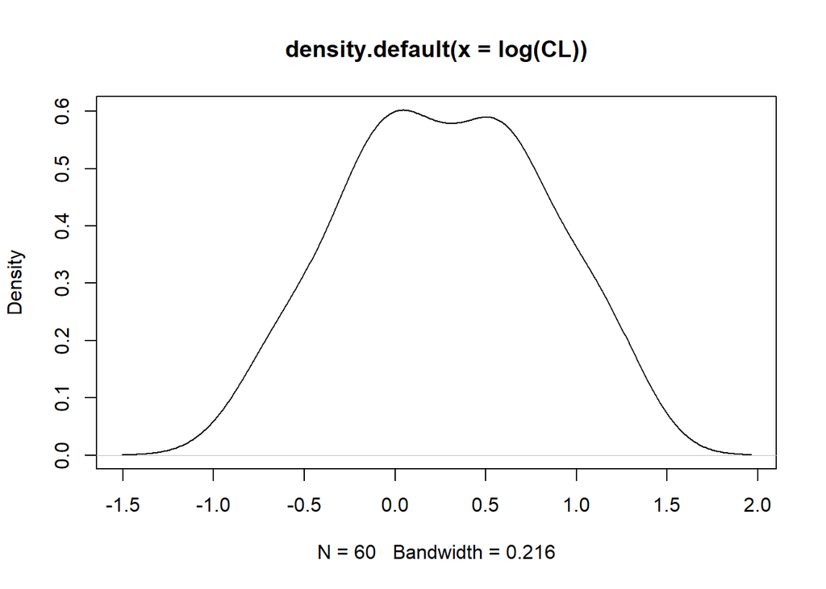

```r
  ebedata[!duplicated(SUBJID), plot(density(log(CL)))]
```

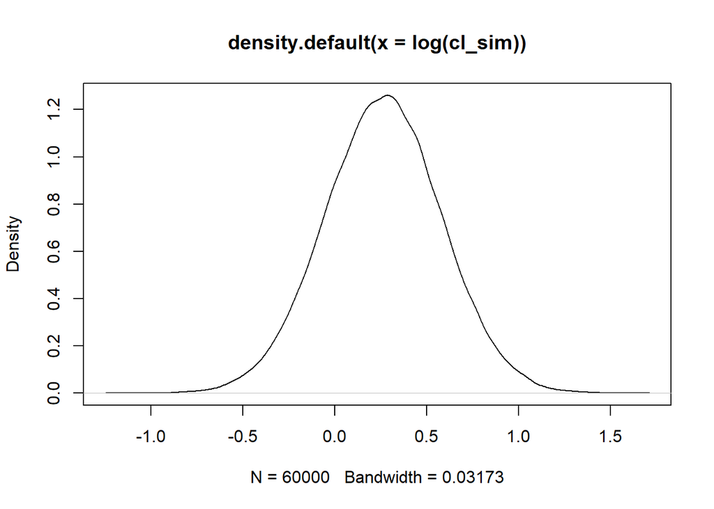

```r
# Overlay estimated clearance values over distriution
  nid <- ebedata[, length(unique(SUBJID))]
  ind_wt <- ebedata[!duplicated(SUBJID), WT]
  cl_sim <- 1.3 * (rep(ind_wt, each = 1000)/70)^0.319 * exp(rnorm(1000*nid, 0, 0.319))
  plot(density(log(cl_sim)))
```

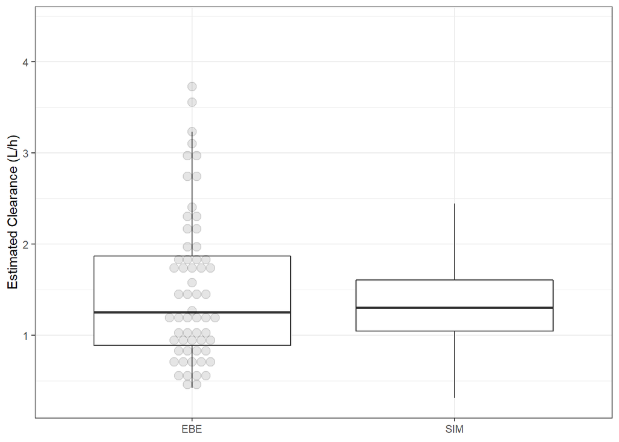

```r
  p <- NULL
  p <- ggplot() + theme_bw()
  p <- p + geom_boxplot(aes(x = "SIM", y = cl_sim), outlier.shape = NA)
  p <- p + geom_boxplot(aes(x = "EBE",
    y = ebedata[!duplicated(SUBJID), CL]), outlier.shape = NA)
  p <- p + geom_dotplot(aes(x = "EBE",
    y = ebedata[!duplicated(SUBJID), CL]),
    stackdir = "center", binaxis = "y", binwidth = 0.1, alpha = 0.1)
  p <- p + labs(x = NULL, y = "Estimated Clearance (L/h)")
  p_boxdot <- p + coord_cartesian(xlim = NULL, ylim = c(0.3, 4.4))
  p_boxdot
```

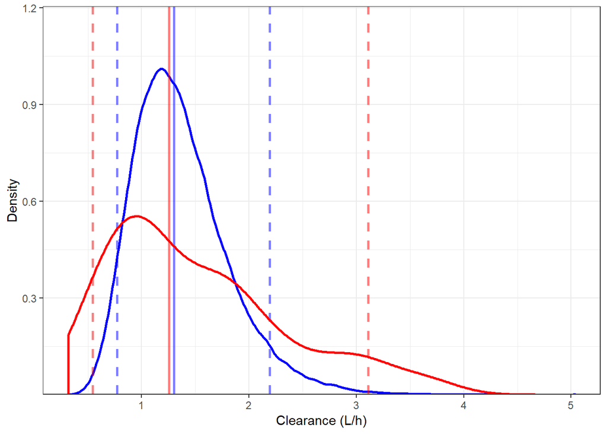

```r
  p <- NULL
  p <- ggplot() + theme_bw()
  p <- p + geom_density(aes(x = cl_sim), size = 1, colour = "blue")
  p <- p + geom_vline(xintercept = median(cl_sim), alpha = 0.5, size = 1, colour = "blue")
  p <- p + geom_vline(xintercept = quantile(cl_sim, probs = c(0.05, 0.95)),
    alpha = 0.5, size = 1, linetype = "dashed", colour = "blue")
  p <- p + geom_density(aes(x = ebedata[!duplicated(SUBJID), CL]),
    colour = "red", alpha = 0.6, size = 1)
  p <- p + geom_vline(xintercept = rep(median(ebedata[!duplicated(SUBJID), CL]), 2),
    alpha = 0.5, size = 1, colour = "red")
  p <- p + geom_vline(xintercept = quantile(ebedata[!duplicated(SUBJID), CL], probs = c(0.05, 0.95)),
    alpha = 0.5, size = 1, linetype = "dashed", colour = "red")
  p <- p + labs(x = "Clearance (L/h)", y = "Density")
  p_dens <- p + coord_cartesian(xlim = NULL, ylim = c(0.055, 1.15))
  p_dens
```

With this plot, the solid lines should overlap, with the vertical lines ideally being as close as possible. The solid curved lines represent the distribution, while the vertical lines represent the median (solid) and 90% confidence intervals (dashed). The model distribution is in blue, while the EBE distribution is in red.

```r
# - - - - - - - - - - - - - - - - - - - - - - - - - - - - - - - - - - - - - - -
# ETA Shrinkage
# Shrinkage implies bias, ideally it is below 20-30%. Negative shrinkage is
#   possible, which describes EBEs with *very* low shrinkage.
# High ETA shrinkage implies that predictions are biased to shrink towards the
#   mean value. High ETA shrinkage will result in EBEs that are not indicative
#   of the individual, but instead the population.
# ETA shrinkage: 1 - SD(ETA)/PPV
  list(
    CL_ETA_shrinkage = 1 - sd(ebedata[!duplicated(SUBJID), ETA1])/0.319,
    Vd_ETA_shrinkage = 1 - sd(ebedata[!duplicated(SUBJID), ETA2])/0.657,
    ka_ETA_shrinkage = 1 - sd(ebedata[!duplicated(SUBJID), ETA3])/1.01
  )
```

```
## $CL_ETA_shrinkage
## [1] -0.6937427
##
## $Vd_ETA_shrinkage
## [1] -0.04153824
##
## $ka_ETA_shrinkage
## [1] 0.3106176
```

Finally, pharmacokinetic model evaluation can be used as well. If EBEs are of a high quality, then individual predictions should also be.

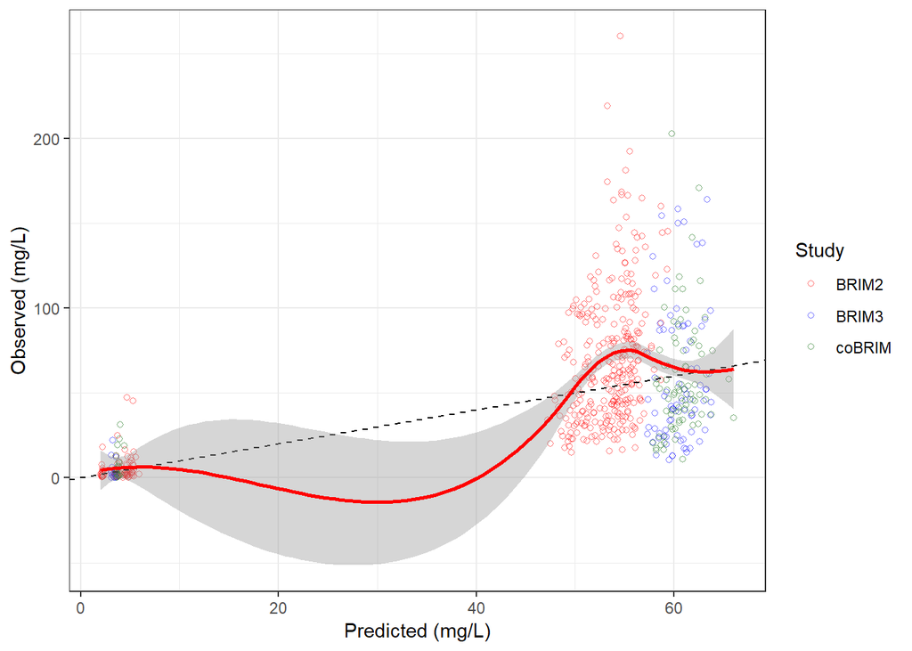

```r
# - - - - - - - - - - - - - - - - - - - - - - - - - - - - - - - - - - - - - - -
# Individual vs Observed - External Model Validation
  pdata <- ebedata[MDV == 0, ]
  myPalette <- c("red", "blue", "darkgreen")

  p <- NULL
  p <- ggplot(aes(x = PRED, y = DV), data = pdata)
  p <- p + theme_bw()
  p <- p + geom_point(aes(colour = STUDYID), size = 1.5, shape = 1, alpha = 0.5)
  p <- p + geom_abline(intercept = 0, slope = 1, linetype = "dashed")
  p <- p + stat_smooth(colour = "red", size = 1, method = "loess")
  p <- p + scale_colour_manual("Study", values = myPalette)
  p <- p + labs(x = "Predicted (mg/L)", y = "Observed (mg/L)")
  p_DVvPRED <- p
  p_DVvPRED
```

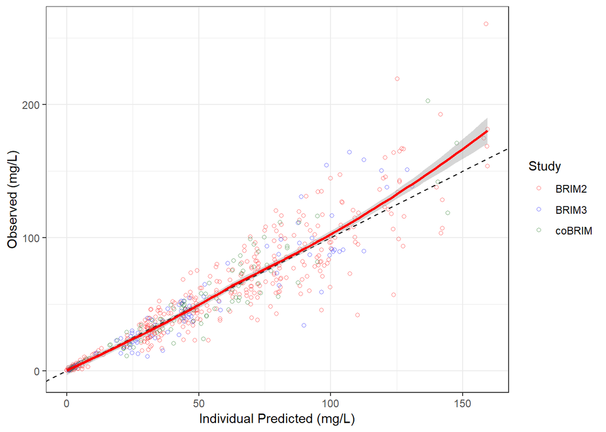

```r
  p <- NULL
  p <- ggplot(aes(x = IPRED, y = DV), data = pdata)
  p <- p + theme_bw()
  p <- p + geom_point(aes(colour = STUDYID), size = 1.5, shape = 1, alpha = 0.5)
  p <- p + geom_abline(intercept = 0, slope = 1, linetype = "dashed")
  p <- p + stat_smooth(colour = "red", size = 1, method = "loess")
  p <- p + scale_colour_manual("Study", values = myPalette)
  p <- p + labs(x = "Individual Predicted (mg/L)", y = "Observed (mg/L)")
  p_DVvIPRE <- p
  p_DVvIPRE
```

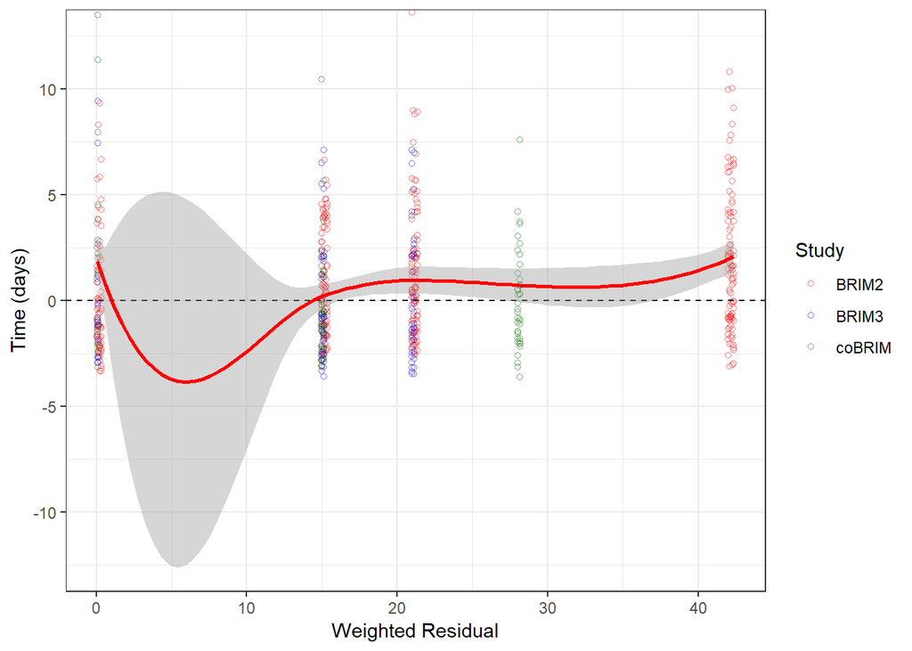

```r
  p <- NULL
  p <- ggplot(aes(x = TIME/24, y = WRES), data = pdata)
  p <- p + theme_bw()
  p <- p + geom_point(aes(colour = STUDYID), size = 1.5, shape = 1, alpha = 0.5)
  p <- p + geom_hline(yintercept = 0, linetype = "dashed")
  p <- p + stat_smooth(colour = "red", size = 1, method = "loess")
  p <- p + scale_colour_manual("Study", values = myPalette)
  p <- p + labs(x = "Weighted Residual", y = "Time (days)")
  p <- p + coord_cartesian(xlim = NULL, ylim = c(-12.5, 12.5))
  p_TIMEvWRES <- p
  p_TIMEvWRES
```

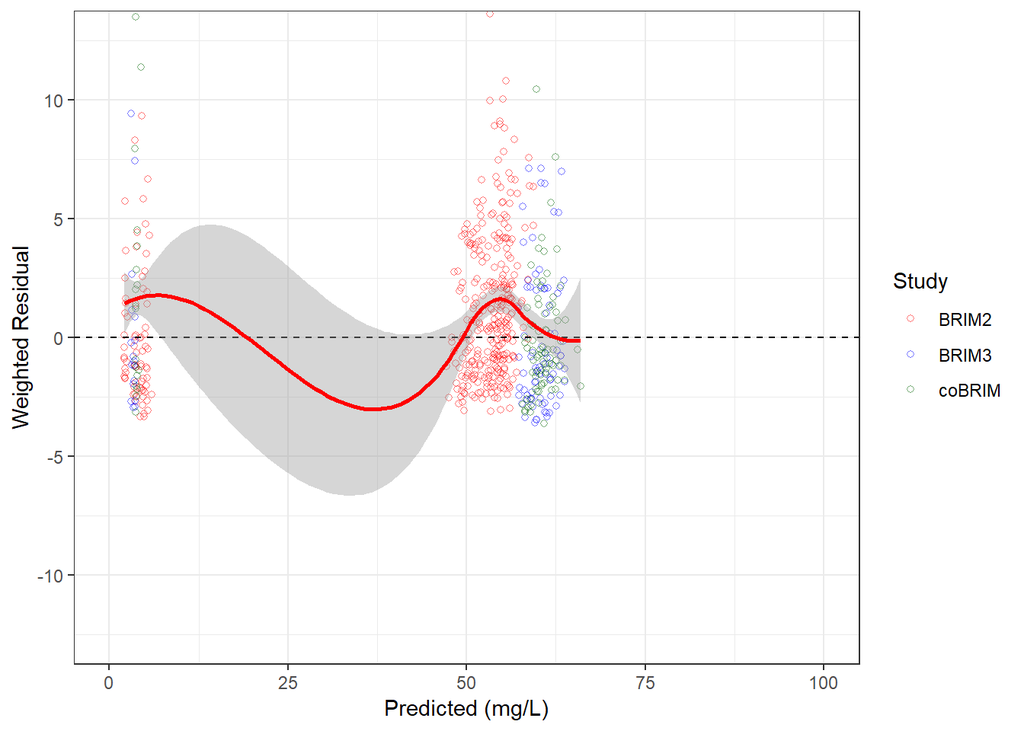

```r
  p <- NULL
  p <- ggplot(aes(x = PRED, y = WRES), data = pdata)
  p <- p + theme_bw()
  p <- p + geom_point(aes(colour = STUDYID), size = 1.5, shape = 1, alpha = 0.5)
  p <- p + geom_hline(yintercept = 0, linetype = "dashed")
  p <- p + stat_smooth(colour = "red", size = 1, method = "loess")
  p <- p + scale_colour_manual("Study", values = myPalette)
  p <- p + labs(x = "Predicted (mg/L)", y = "Weighted Residual")
  p <- p + coord_cartesian(xlim = c(0, 100), ylim = c(-12.5, 12.5))
  p_PREDvWRES <- p
  p_PREDvWRES
```